# Interaction with Time

Polisma Yadav

November 20, 2021

```r
# Use this R-Chunk to import all your datasets!
#load tickers
tickers_today <- c("CXW", "F", "GM", "JCP", "KR", "WDC", "NKE","T", "WDAY", "WFC", "WMT")
#get date,symbol and price
stocks <- tq_get(tickers_today) %>% select(date, symbol, adjusted)
stock <- stocks %>% pivot_wider(names_from = symbol, values_from = adjusted)
stk <- tk_xts(stock, date_var = date)
today <- now() #todays date from system
five_years <- today - dyears(x = 5) #date from 5 years ago from today
```

## Background

Your data science income has ballooned, and you need to find somewhere to invest $25,000 that you have saved over the last year. You have a savvy investment friend that is kind enough to tell you ten stocks she has been watching during the last year. You will need to visualize the last five years performance to help in the conversation with your friend.

Your friend is going to give you his tickers at the beginning of your half-hour meeting with her (she is a busy friend). You will need to build an .Rmd file that will build a suite of visualizations rapidly for your conversation. You will need a series of stock performance graphics using library(dygraphs) and library(ggplot2). In real life, you might use one or the other, but this task is built to help you move from ts and xts to tidy objects for visualization

## Data Wrangling & Visualization

```r
#dygraph
dygraph(stk) %>%
  dyRangeSelector(dateWindow = c(five_years, today)) %>%
  dyRebase(value = 25000)
```

[interactive chart not shown]

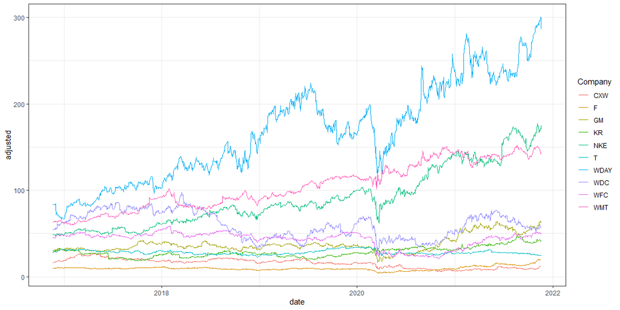

```r
#ggplot
stocks %>% filter(date >= five_years) %>%
ggplot(aes(x = date, y = adjusted, color = symbol)) +
  geom_line() +
  labs(color = "Company") +
  theme_bw()
```

## Conclusions

I have included two graphs(dygraph and a ggplot) to show the performance of given tickers. In the dygraph you can see the performance of each stock on how it would perform over the last 5 years had I invested $25,000 in any of them 5 years ago. In the ggplot you can see the stock performance of the tickers given and easily see the performance of all 10 companies as they are each represented by a different color.